# SOM - Read and plot data from the manuscript Paixao et al.

Paixao et al. Using Mechanical experiments to study Ground Stone Tool use: exploring the formation of percussive and grinding wear traces on Limestone tools

28/09/2020

**Brief description of the script**

This R markdown document reads, summarizes and plots data for the manuscript Paixao et al. The document contains:

1. Manuscript tables
2. Manuscript figures (data plots)
3. Supplementary material, including extra tables and figures (data plots)

This R project and respective script follows the procedures described by Marwick et al. 2017.

To compile this markdown document do not delete or move files from their original folders. Please note that the tables and figures in this file do not match the numbering in the original manuscript.

For any questions, comments and inputs, please contact:

Joao Marreiros, marreiros@rgzm.de, or Eduardo Paixao, paixao@rgzm.de

# Load data into R project

*Imported files are in: ‘../analysis/raw_data’*

*Figures are saved in: ‘../analysis/plots’*

*Tables are saved in: ‘../analysis/derived_data’*

1. Load libraries and datasets

```r
# Load required libraries

library(tidyverse)
library(utils)
library(knitr)
library(janitor)
library(kableExtra)
library(GGally)
library(doBy)
library(ggpubr)
library(ggfortify)
# Import datasets

gisdata <- read.csv("../analysis/raw_data/gisdata.csv")
confocaldata <- read_csv("../analysis/raw_data/confocaldata.csv")
```

In this study, two datasets are used:

1. **gisdata.csv**: dataset for the QGIS analysis

```r
str(gisdata)
```

```
## 'data.frame':    355 obs. of  12 variables:
##  $ sample   : chr  "id2-5" "id2-5" "id3-3" "id3-3" ...
##  $ cycle    : chr  "before" "before" "before" "before" ...
##  $ parameter: chr  "tri" "tri" "tri" "tri" ...
##  $ motion   : chr  "Impact" "Impact" "Impact" "Impact" ...
##  $ material : chr  "Flint" "Flint" "Flint" "Flint" ...
##  $ id       : int  0 1 0 1 2 3 4 0 1 0 ...
##  $ elev_min : num  0 0.01 0 0.01 0.02 0.03 0.04 0 0.01 0 ...
##  $ elev_max : num  0.01 0.02 0.01 0.02 0.03 0.04 0.05 0.01 0.02 0.01 ...
##  $ nparts   : int  1007 1010 131 165 47 10 1 11 12 6 ...
##  $ npoints  : int  67487 59648 14961 16143 3142 423 7 6559 1248 8538 ...
##  $ perimeter: num  485.2 446 160.6 177.5 32.8 ...
##  $ area     : num  204.49 17.48 83.65 38.12 1.83 ...
```

2. **confocaldata.csv**: dataset for the Confocal microscopy surface texture analysis

```r
str(confocaldata)
```

```
## tibble [25 × 54] (S3: spec_tbl_df/tbl_df/tbl/data.frame)
##  $ Name                               : chr [1:25] "Lime2-5_LSM_50x075_suf1_Topo > Leveled (LS-plane) > Form removed (LS-poly 3) > Outliers removed > Thresholded (0.1000 %" "Lime2-5_LSM_50x075_suf2_Topo > Leveled (LS-plane) > Form removed (LS-poly 3) > Outliers removed > Thresholded (0.1000 %" "L…
##  $ Created on                         : chr [1:25] "6/24/2020 12:03:05 PM" "6/24/2020 12:21:59 PM" "6/24/2020 1:26:11 PM" "9/14/2020 12:02:32 PM" ...
##  $ sample                             : chr [1:25] "id2-5" "id2-5" "id2-5" "id3-3" ...
##  $ motion                             : chr [1:25] "impact" "impact" "impact" "impact" ...
##  $ workedmaterial                     : chr [1:25] "flint" "flint" "flint" "flint" ...
##  $ Studiable type                     : chr [1:25] "Surface" "Surface" "Surface" "Surface" ...
##  $ Axis name - X                      : chr [1:25] "X" "X" "X" "X" ...
##  $ Axis length - X                    : num [1:25] 255 255 255 255 255 ...
##  $ Axis size - X                      : num [1:25] 3000 3000 3000 1024 1024 ...
##  $ Axis spacing - X                   : num [1:25] 85.2 85.2 85.2 249.6 249.6 ...
##  $ Axis name - Y                      : chr [1:25] "Y" "Y" "Y" "Y" ...
##  $ Axis length - Y                    : num [1:25] 255 255 255 255 255 ...
##  $ Axis size - Y                      : num [1:25] 3000 3000 3000 1024 1024 ...
##  $ Axis spacing - Y                   : num [1:25] 85.2 85.2 85.2 249.6 249.6 ...
##  $ Axis name - Z                      : chr [1:25] "Z" "Z" "Z" "Z" ...
##  $ Layer type - Z                     : chr [1:25] "Topography" "Topography" "Topography" "Topography" ...
##  $ Axis length - Z                    : num [1:25] 8.3 30.6 14.9 48.6 23 ...
##  $ Axis size - Z                      : num [1:25] 128164 333950 130813 193492 260079 ...
##  $ Axis spacing - Z                   : num [1:25] 0.0647 0.0916 0.1139 0.2511 0.0884 ...
##  $ NM-points ratio - Z                : num [1:25] 0 0 0 0 0 0 0 0 0 0 ...
##  $ Sq                                 : num [1:25] 0.836 4.619 2.321 5.348 3.491 ...
##  $ Ssk                                : num [1:25] 0.997 0.107 0.142 -0.491 0.201 ...
##  $ Sku                                : num [1:25] 8.63 4.48 3.11 5.97 3.46 ...
##  $ Sp                                 : num [1:25] 4.8 15.02 7.46 23 11.88 ...
##  $ Sv                                 : num [1:25] 3.49 15.58 7.45 25.58 11.11 ...
##  $ Sz                                 : num [1:25] 8.3 30.6 14.9 48.6 23 ...
##  $ Sa                                 : num [1:25] 0.572 3.244 1.819 3.887 2.699 ...
##  $ Smr                                : num [1:25] 0.464 0.497 0.448 0.18 0.354 ...
##  $ Smc                                : num [1:25] 0.775 5.691 2.944 5.799 4.436 ...
##  $ Sxp                                : num [1:25] 1.53 10.61 4.3 11.65 6.74 ...
##  $ Sal                                : num [1:25] 13.5 18.9 20.1 18.7 22.9 ...
##  $ Str                                : num [1:25] 0.371 0.416 0.592 0.468 0.803 ...
##  $ Std                                : num [1:25] 149 65 150 51 124 ...
##  $ Sdq                                : num [1:25] 0.328 1.153 0.688 1.126 0.897 ...
##  $ Sdr                                : num [1:25] 4.36 20.02 16.47 31.23 24.6 ...
##  $ Vm                                 : num [1:25] 0.0866 0.3378 0.1331 0.3133 0.2114 ...
##  $ Vv                                 : num [1:25] 0.861 6.029 3.078 6.113 4.648 ...
##  $ Vmp                                : num [1:25] 0.0866 0.3378 0.1331 0.3133 0.2114 ...
##  $ Vmc                                : num [1:25] 0.528 3.111 2.097 3.932 3.146 ...
```

[output cut: 57 more lines]

```
##   ..   Vvv = col_double(),
##   ..   `Maximum depth of furrows` = col_double(),
##   ..   `Mean depth of furrows` = col_double(),
##   ..   `Mean density of furrows` = col_double(),
##   ..   `First direction` = col_double(),
##   ..   `Second direction` = col_double(),
##   ..   `Third direction` = col_double(),
##   ..   Isotropy = col_double(),
##   ..   `Lengthscale anisotropy Sfrax epLsar` = col_character(),
##   ..   `Lengthscale anisotropy NewEplsar` = col_character(),
##   ..   `Fractal complexity Asfc` = col_double(),
##   ..   `Scale of max complexity Smfc` = col_double(),
##   ..   HAsfc9 = col_double(),
##   ..   HAsfc81 = col_double()
##   .. )
```

# GIS analysis, Terrain analysis for Slope and TRI

## Slope

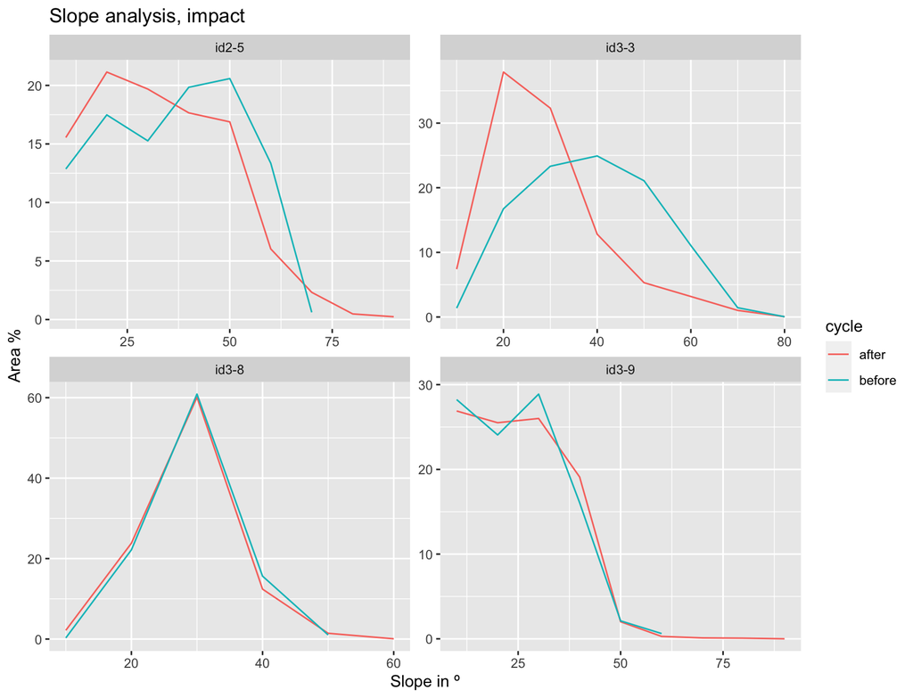

```r
# Compute proportions for perimeter and area grouped by sample and parameter

slope <- filter(gisdata, parameter == "slope")
slopebefore <- filter(slope, cycle == "before")
slopeafter <-  filter(slope, cycle == "after")

# before experimental cycles (natural surfaces)

id2.5before <- filter(slopebefore, sample == "id2-5")
id3.3before <- filter(slopebefore, sample == "id3-3")
id3.8before <- filter(slopebefore, sample == "id3-8")
id3.9before <- filter(slopebefore, sample == "id3-9")
id6.1before <- filter(slopebefore, sample == "id6-1")
id6.3before <- filter(slopebefore, sample == "id6-3")
id6.6before <- filter(slopebefore, sample == "id6-6")
id6.7before <- filter(slopebefore, sample == "id6-7")

id2.5before <- id2.5before %>%
  group_by(sample) %>%
  mutate(
    areaperc = area / sum(area) * 100,
    perimperc = perimeter / sum(perimeter) * 100)

id3.3before <- id3.3before %>%
  group_by(sample) %>%
  mutate(
    areaperc = area / sum(area) * 100,
    perimperc = perimeter / sum(perimeter) * 100)

id3.8before <- id3.8before %>%
  group_by(sample) %>%
  mutate(
    areaperc = area / sum(area) * 100,
    perimperc = perimeter / sum(perimeter) * 100)

id3.9before <- id3.9before %>%
  group_by(sample) %>%
  mutate(
    areaperc = area / sum(area) * 100,
    perimperc = perimeter / sum(perimeter) * 100)

id6.1before <- id6.1before %>%
  group_by(sample) %>%
  mutate(
    areaperc = area / sum(area) * 100,
    perimperc = perimeter / sum(perimeter) * 100)

id6.3before <- id6.3before %>%
  group_by(sample) %>%
  mutate(
    areaperc = area / sum(area) * 100,
    perimperc = perimeter / sum(perimeter) * 100)

id6.6before <- id6.6before %>%
  group_by(sample) %>%
  mutate(
    areaperc = area / sum(area) * 100,
    perimperc = perimeter / sum(perimeter) * 100)

id6.7before <- id6.7before %>%
  group_by(sample) %>%
  mutate(
    areaperc = area / sum(area) * 100,
    perimperc = perimeter / sum(perimeter) * 100)

# after experimental cycles

id2.5after <- filter(slopeafter, sample == "id2-5")
id3.3after <- filter(slopeafter, sample == "id3-3")
id3.8after <- filter(slopeafter, sample == "id3-8")
id3.9after <- filter(slopeafter, sample == "id3-9")
id6.1after <- filter(slopeafter, sample == "id6-1")
id6.3after <- filter(slopeafter, sample == "id6-3")
id6.6after <- filter(slopeafter, sample == "id6-6")
id6.7after <- filter(slopeafter, sample == "id6-7")

id2.5after <- id2.5after %>%
  group_by(sample) %>%
  mutate(
    areaperc = area / sum(area) * 100,
    perimperc = perimeter / sum(perimeter) * 100)

id3.3after <- id3.3after %>%
  group_by(sample) %>%
  mutate(
    areaperc = area / sum(area) * 100,
    perimperc = perimeter / sum(perimeter) * 100)

id3.8after <- id3.8after %>%
  group_by(sample) %>%
  mutate(
    areaperc = area / sum(area) * 100,
    perimperc = perimeter / sum(perimeter) * 100)

id3.9after <- id3.9after %>%
  group_by(sample) %>%
  mutate(
    areaperc = area / sum(area) * 100,
    perimperc = perimeter / sum(perimeter) * 100)

id6.1after <- id6.1after %>%
  group_by(sample) %>%
  mutate(
    areaperc = area / sum(area) * 100,
    perimperc = perimeter / sum(perimeter) * 100)

id6.3after <- id6.3after %>%
  group_by(sample) %>%
  mutate(
    areaperc = area / sum(area) * 100,
    perimperc = perimeter / sum(perimeter) * 100)

id6.6after <- id6.6after %>%
  group_by(sample) %>%
  mutate(
    areaperc = area / sum(area) * 100,
    perimperc = perimeter / sum(perimeter) * 100)

id6.7after <- id6.7after %>%
  group_by(sample) %>%
  mutate(
    areaperc = area / sum(area) * 100,
    perimperc = perimeter / sum(perimeter) * 100)


newslope <- do.call("rbind", list(id2.5before, id3.3before, id3.8before, id3.9before, id6.1before, id6.3before, id6.6before, id6.7before, id2.5after, id3.3after, id3.8after, id3.9after, id6.1after, id6.3after, id6.6after, id6.7after))

# save output

write_csv(newslope,"../analysis/derived_data/newslope.csv")

# Plot data

# Area %

impactdf <- filter(newslope, motion == "Impact")
grinding <- filter(newslope, motion == "Grinding")


areaimpact <- ggplot(impactdf, aes(x = elev_max, y = areaperc, colour = cycle)) +
  geom_line() +
  facet_wrap(~sample, scale = "free") +
  ggtitle("Slope analysis, impact") +
  ylab("Area %") +
  xlab("Slope in º")

areaimpact
```

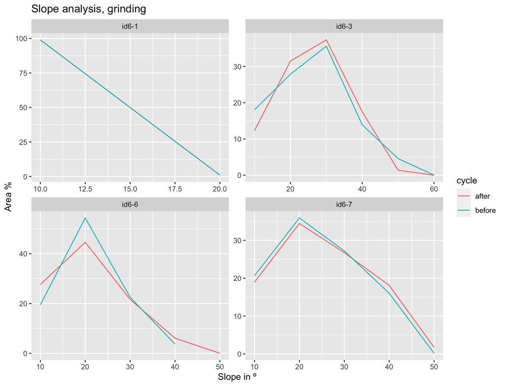

```r
ggsave("../analysis/plots/slopeareaimpact.png")
areagrinding <- ggplot(grinding, aes(x = elev_max, y = areaperc, colour = cycle)) +
  geom_line() +
  facet_wrap(~sample, scale = "free") +
  ggtitle("Slope analysis, grinding") +
  ylab("Area %") +
  xlab("Slope in º")

areagrinding
```

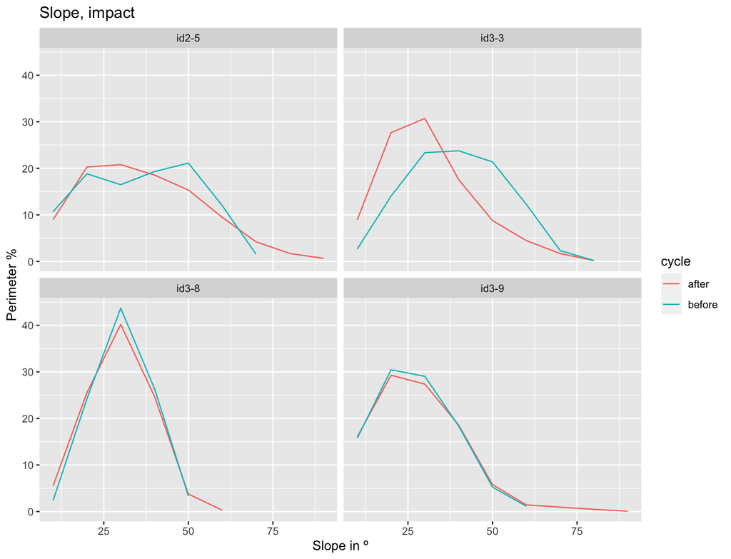

```r
ggsave("../analysis/plots/slopeareagrinding.png")
# Perimeter %

perimimpact <- ggplot(impactdf, aes(x = elev_max, y = perimperc, colour = cycle)) +
  geom_line() +
  facet_wrap(~sample) +
  ggtitle("Slope, impact") +
  ylab("Perimeter %") +
  xlab("Slope in º")

perimimpact
```

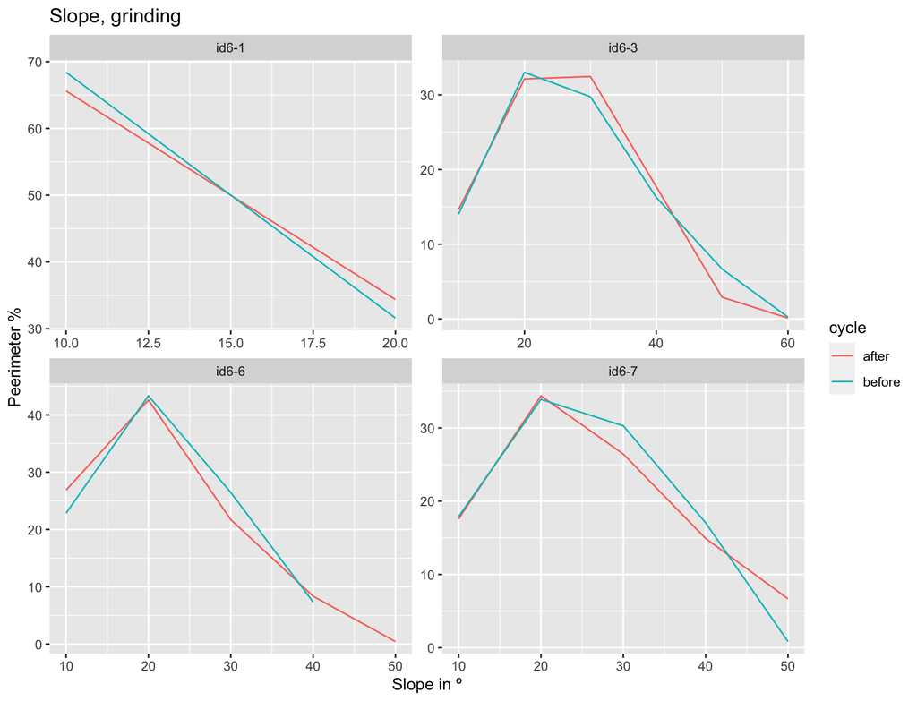

```r
ggsave("../analysis/plots/slopeperimimpact.png")
perimgrinding <- ggplot(grinding, aes(x = elev_max, y = perimperc, colour = cycle)) +
  geom_line() +
  facet_wrap(~sample, scale = "free") +
  ggtitle("Slope, grinding") +
  ylab("Peerimeter %") +
  xlab("Slope in º")

perimgrinding
```

```r
ggsave("../analysis/plots/slopeperimgrinding.png")
```

## TRI (Terrain roughness index)

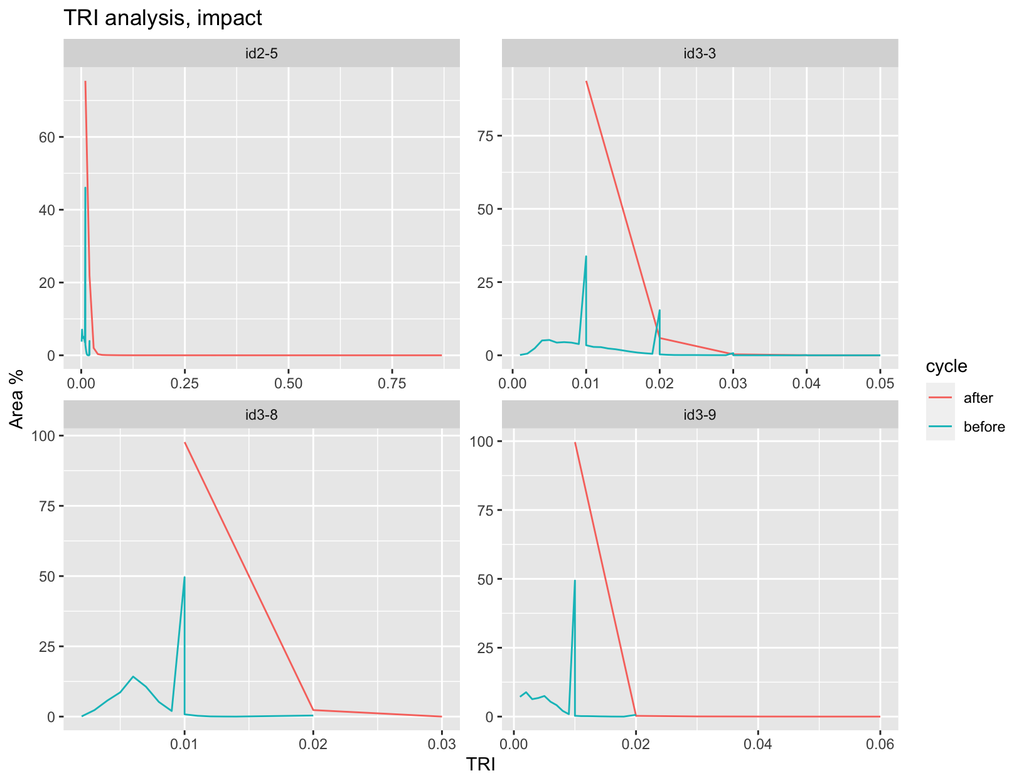

```r
tri <- filter(gisdata, parameter == "tri")
tribefore <- filter(tri, cycle == "before")
triafter <- filter(tri, cycle =="after")


# before experimental cycles (natural surfaces)

id2.5before <- filter(tribefore, sample == "id2-5")
id3.3before <- filter(tribefore, sample == "id3-3")
id3.8before <- filter(tribefore, sample == "id3-8")
id3.9before <- filter(tribefore, sample == "id3-9")
id6.1before <- filter(tribefore, sample == "id6-1")
id6.3before <- filter(tribefore, sample == "id6-3")
id6.6before <- filter(tribefore, sample == "id6-6")
id6.7before <- filter(tribefore, sample == "id6-7")

id2.5before <- id2.5before %>%
  group_by(sample) %>%
  mutate(
    areaperc = area / sum(area) * 100,
    perimperc = perimeter / sum(perimeter) * 100)

id3.3before <- id3.3before %>%
  group_by(sample) %>%
  mutate(
    areaperc = area / sum(area) * 100,
    perimperc = perimeter / sum(perimeter) * 100)

id3.8before <- id3.8before %>%
  group_by(sample) %>%
  mutate(
    areaperc = area / sum(area) * 100,
    perimperc = perimeter / sum(perimeter) * 100)

id3.9before <- id3.9before %>%
  group_by(sample) %>%
  mutate(
    areaperc = area / sum(area) * 100,
    perimperc = perimeter / sum(perimeter) * 100)

id6.1before <- id6.1before %>%
  group_by(sample) %>%
  mutate(
    areaperc = area / sum(area) * 100,
    perimperc = perimeter / sum(perimeter) * 100)

id6.3before <- id6.3before %>%
  group_by(sample) %>%
  mutate(
    areaperc = area / sum(area) * 100,
    perimperc = perimeter / sum(perimeter) * 100)

id6.6before <- id6.6before %>%
  group_by(sample) %>%
  mutate(
    areaperc = area / sum(area) * 100,
    perimperc = perimeter / sum(perimeter) * 100)

id6.7before <- id6.7before %>%
  group_by(sample) %>%
  mutate(
    areaperc = area / sum(area) * 100,
    perimperc = perimeter / sum(perimeter) * 100)


# after experimental cycles

id2.5after <- filter(triafter, sample == "id2-5")
id3.3after <- filter(triafter, sample == "id3-3")
id3.8after <- filter(triafter, sample == "id3-8")
id3.9after <- filter(triafter, sample == "id3-9")
id6.1after <- filter(triafter, sample == "id6-1")
id6.3after <- filter(triafter, sample == "id6-3")
id6.6after <- filter(triafter, sample == "id6-6")
id6.7after <- filter(triafter, sample == "id6-7")

id2.5after <- id2.5after %>%
  group_by(sample) %>%
  mutate(
    areaperc = area / sum(area) * 100,
    perimperc = perimeter / sum(perimeter) * 100)

id3.3after <- id3.3after %>%
  group_by(sample) %>%
  mutate(
    areaperc = area / sum(area) * 100,
    perimperc = perimeter / sum(perimeter) * 100)

id3.8after <- id3.8after %>%
  group_by(sample) %>%
  mutate(
    areaperc = area / sum(area) * 100,
    perimperc = perimeter / sum(perimeter) * 100)

id3.9after <- id3.9after %>%
  group_by(sample) %>%
  mutate(
    areaperc = area / sum(area) * 100,
    perimperc = perimeter / sum(perimeter) * 100)

id6.1after <- id6.1after %>%
  group_by(sample) %>%
  mutate(
    areaperc = area / sum(area) * 100,
    perimperc = perimeter / sum(perimeter) * 100)

id6.3after <- id6.3after %>%
  group_by(sample) %>%
  mutate(
    areaperc = area / sum(area) * 100,
    perimperc = perimeter / sum(perimeter) * 100)

id6.6after <- id6.6after %>%
  group_by(sample) %>%
  mutate(
    areaperc = area / sum(area) * 100,
    perimperc = perimeter / sum(perimeter) * 100)

id6.7after <- id6.7after %>%
  group_by(sample) %>%
  mutate(
    areaperc = area / sum(area) * 100,
    perimperc = perimeter / sum(perimeter) * 100)


newtri <- do.call("rbind", list(id2.5before, id3.3before, id3.8before, id3.9before, id6.1before, id6.3before, id6.6before, id6.7before, id2.5after, id3.3after, id3.8after, id3.9after, id6.1after, id6.3after, id6.6after, id6.7after))

# save output

write_csv(newtri,"../analysis/derived_data/newtri.csv")

# Plot data

# Area %

impactdf <- filter(newtri, motion == "Impact")
grinding <- filter(newtri, motion == "Grinding")

areaimpact <- ggplot(impactdf, aes(x = elev_max, y = areaperc, colour = cycle)) +
  geom_line() +
  facet_wrap(~sample, scale = "free") +
  ggtitle("TRI analysis, impact") +
  ylab("Area %") +
  xlab("TRI")

areaimpact
```

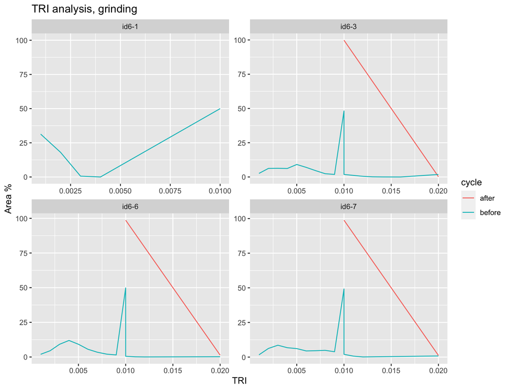

```r
ggsave("../analysis/plots/triareaimpact.png")
areagrinding <- ggplot(grinding, aes(x = elev_max, y = areaperc, colour = cycle)) +
  geom_line() +
  facet_wrap(~sample, scale = "free") +
  ggtitle("TRI analysis, grinding") +
  ylab("Area %") +
  xlab("TRI")

areagrinding
```

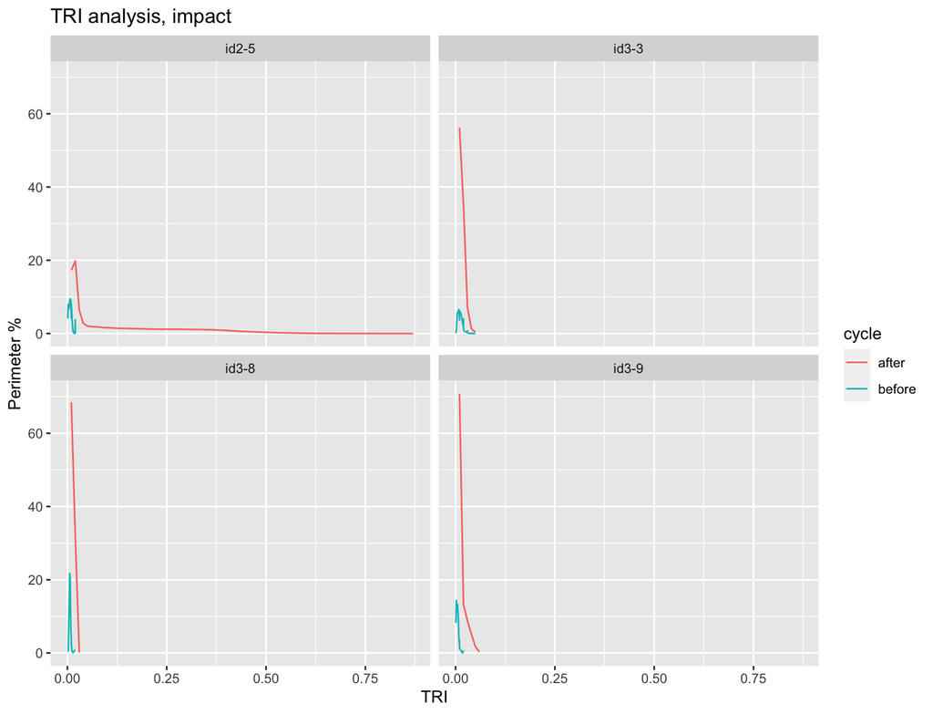

```r
ggsave("../analysis/plots/triareagrinding.png")
# Perimeter %

perimimpact <- ggplot(impactdf, aes(x = elev_max, y = perimperc, colour = cycle)) +
  geom_line() +
  facet_wrap(~sample) +
  ggtitle("TRI analysis, impact") +
  ylab("Perimeter %") +
  xlab("TRI")

perimimpact
```

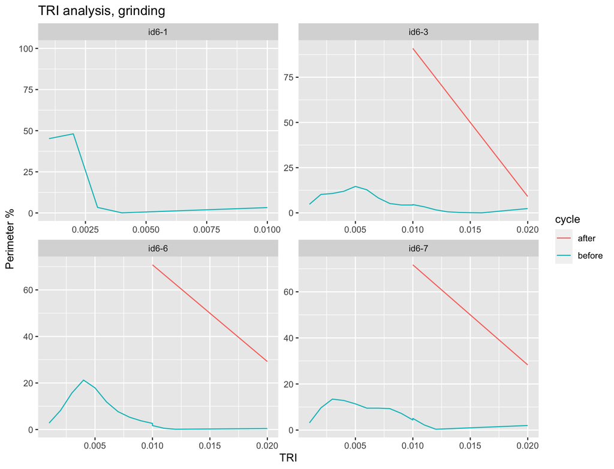

```r
ggsave("../analysis/plots/triperimimpact.png")
perimgrinding <- ggplot(grinding, aes(x = elev_max, y = perimperc, colour = cycle)) +
  geom_line() +
  facet_wrap(~sample, scale = "free") +
  ggtitle("TRI analysis, grinding") +
  ylab("Perimeter %") +
  xlab("TRI")

perimgrinding
```

```r
ggsave("../analysis/plots/triperimgrinding.png")
```

# Import, summarize and plot all Confocal data

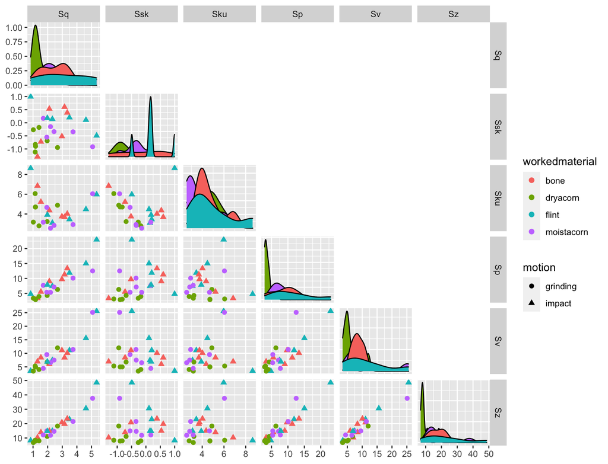

```r
# Compute descriptive statistics

# Scatterplot matrix for the ISO 25178 Area scale, Height and volume parameters

data(confocaldata, package = "reshape")
ggpairs(data=confocaldata,
        columns = c(21:26),
        cardinality_threshold = 30,
        mapping = ggplot2::aes(color = workedmaterial, shape = motion),
        lower = list(continuous = wrap("points", alpha = 1, size = 2)),
        upper = list(continuous = "blank"),
        legend = c(2,1)
        ) +

    theme(legend.position = "right") +
  labs(fill = "Micro polish type")
```

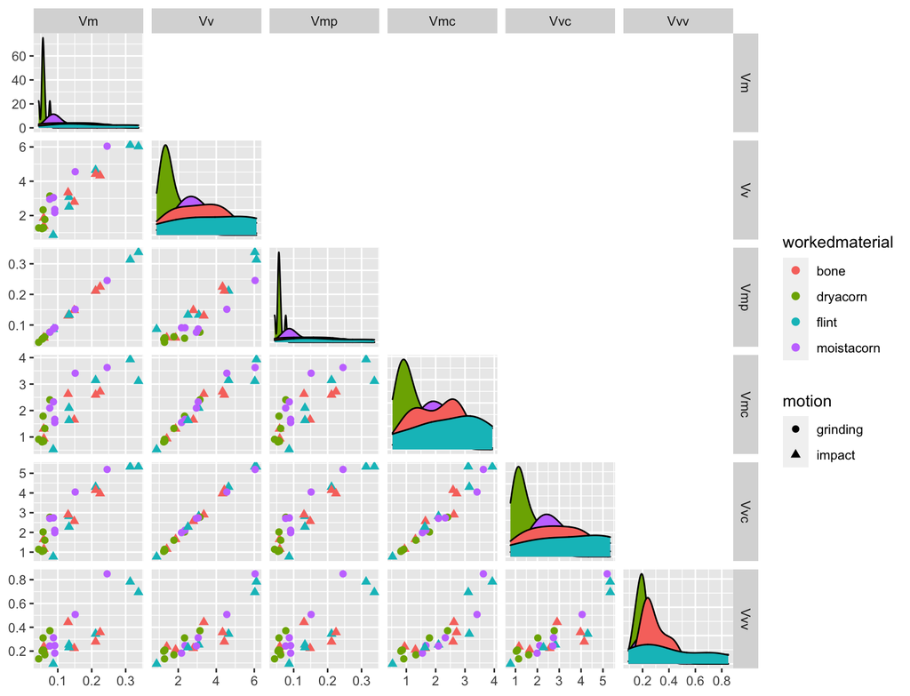

```r
ggsave("../analysis/plots/confocalarea.png")
ggpairs(data=confocaldata,
        columns = c(36:41),
        cardinality_threshold = 30,
        mapping = ggplot2::aes(color = workedmaterial, shape = motion),
        lower = list(continuous = wrap("points", alpha = 1, size = 2)),
        upper = list(continuous = "blank"),
        legend = c(2,1)
        ) +

    theme(legend.position = "right") +
  labs(fill = "Micro polish type")
```

```r
ggsave("../analysis/plots/confocalvolume.png")
# compute descriptive statistics

nminmaxmeanmedsd <- function(x){
    y <- x[!is.na(x)]
    n_test <- length(y)
    min_test <- min(y)
    max_test <- max(y)
    mean_test <- mean(y)
    med_test <- median(y)
    sd_test <- sd(y)
    out <- c(n_test, min_test, max_test, mean_test, med_test, sd_test)
    names(out) <- c("n", "min", "max", "mean", "median", "sd")
    return(out)
}

positions <- c(1:5,21:27,36:41)
df <- confocaldata %>%
  select(positions)
```

```
## Note: Using an external vector in selections is ambiguous.
## ℹ Use `all_of(positions)` instead of `positions` to silence this message.
## ℹ See <https://tidyselect.r-lib.org/reference/faq-external-vector.html>.
```

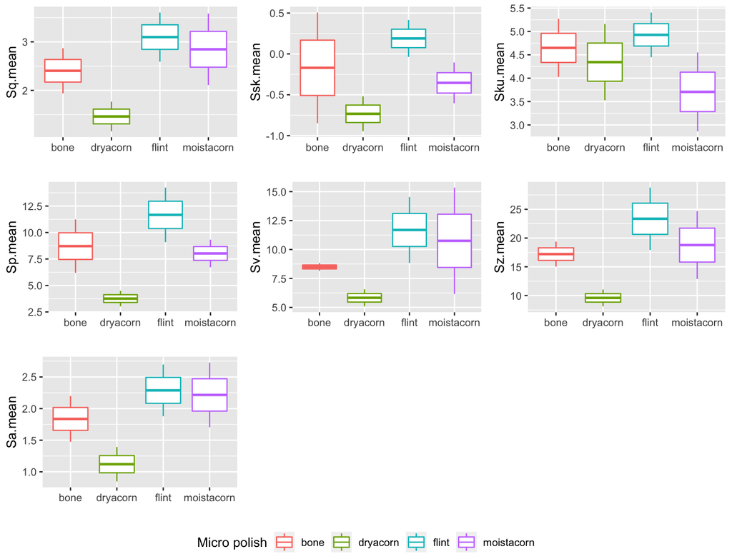

```r
num.var <- 5:length(df)

confostats <- summaryBy(.~sample+workedmaterial, data=df[c("sample", "motion","workedmaterial", names(df)[num.var])], FUN=nminmaxmeanmedsd)

write_csv(confostats, "../analysis/derived_data/confostats.csv")

# Plot confostats for the ISO 25178 Area-scale, Height and volume parameters
# select parameter from datase

# firts Height parameters

heightconfostats <- select(confostats,sample,workedmaterial, Sq.mean,Ssk.mean,Sku.mean,Sp.mean,Sv.mean,Sz.mean,Sa.mean)

p1 <- ggplot(heightconfostats, aes(x=workedmaterial, y=Sq.mean, colour=workedmaterial)) +
  geom_boxplot() +
  labs(x="", colour="Micro polish")

p2 <- ggplot(heightconfostats, aes(x=workedmaterial, y=Ssk.mean, colour=workedmaterial)) +
  geom_boxplot() +
  labs(x="", colour="Micro polish")

p3 <- ggplot(heightconfostats, aes(x=workedmaterial, y=Sku.mean, colour=workedmaterial)) +
  geom_boxplot() +
  labs(x="", colour="Micro polish")

p4 <- ggplot(heightconfostats, aes(x=workedmaterial, y=Sp.mean, colour=workedmaterial)) +
  geom_boxplot() +
  labs(x="", colour="Micro polish")

p5 <- ggplot(heightconfostats, aes(x=workedmaterial, y=Sv.mean, colour=workedmaterial)) +
  geom_boxplot() +
  labs(x="", colour="Micro polish")

p6 <- ggplot(heightconfostats, aes(x=workedmaterial, y=Sz.mean, colour=workedmaterial)) +
  geom_boxplot() +
  labs(x="", colour="Micro polish")

p7 <- ggplot(heightconfostats, aes(x=workedmaterial, y=Sa.mean, colour=workedmaterial)) +
  geom_boxplot() +
  labs(x="", colour="Micro polish")

ggarrange(p1, p2, p3, p4, p5, p6, p7, ncol = 3, nrow = 3, common.legend = TRUE, legend="bottom")
```

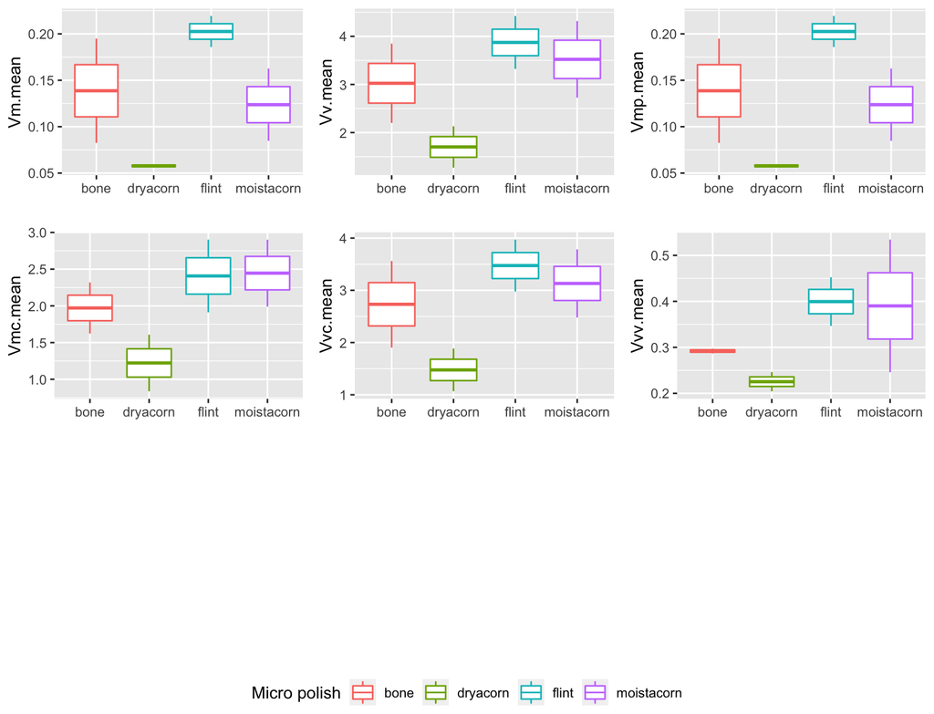

```r
ggsave("../analysis/plots/confostatsarea.png")
# Now Volume parameters

volumeconfostats <- select(confostats,sample,workedmaterial, Vm.mean,Vv.mean,Vmp.mean,Vmc.mean,Vvc.mean,Vvv.mean)

p8 <- ggplot(volumeconfostats, aes(x=workedmaterial, y=Vm.mean, colour=workedmaterial)) +
  geom_boxplot() +
  labs(x="", colour="Micro polish")

p9 <- ggplot(volumeconfostats, aes(x=workedmaterial, y=Vv.mean, colour=workedmaterial)) +
  geom_boxplot() +
  labs(x="", colour="Micro polish")

p10 <- ggplot(volumeconfostats, aes(x=workedmaterial, y=Vmp.mean, colour=workedmaterial)) +
  geom_boxplot() +
  labs(x="", colour="Micro polish")

p11 <- ggplot(volumeconfostats, aes(x=workedmaterial, y=Vmc.mean, colour=workedmaterial)) +
  geom_boxplot() +
  labs(x="", colour="Micro polish")

p12 <- ggplot(volumeconfostats, aes(x=workedmaterial, y=Vvc.mean, colour=workedmaterial)) +
  geom_boxplot() +
  labs(x="", colour="Micro polish")

p13 <- ggplot(volumeconfostats, aes(x=workedmaterial, y=Vvv.mean, colour=workedmaterial)) +
  geom_boxplot() +
  labs(x="", colour="Micro polish")

ggarrange(p8, p9, p10, p11, p12, p13, ncol = 3, nrow = 3, common.legend = TRUE, legend="bottom")
```

```r
ggsave("../analysis/plots/confostatvolume.png")
```